# **AllLife Bank Customer Segmentation**

## **Solution by: 'Femi Bolarinwa**

## **Context**

**AllLife Bank wants to focus on its credit card customer base** in the next financial year. They have been advised by their marketing research team, that the penetration in the market can be improved. Based on this input, the marketing team proposes to run personalized campaigns to target new customers as well as upsell to existing customers.

Another insight from the market research was that the customers perceive the support services of the bank poorly. Based on this, the operations team wants to upgrade the service delivery model, to ensure that customers' queries are resolved faster. The head of marketing and the head of delivery, both decide to reach out to the Data Science team for help.

## **Objective**

**Identify different segments in the existing customer base**, taking into account their spending patterns as well as past interactions with the bank.

## **About the data**

Data is available on customers of the bank with their credit limit, the total number of credit cards the customer has, and different channels through which the customer has contacted the bank for any queries. These different channels include visiting the bank, online, and through a call center.

- **Sl_no** - Customer Serial Number
- **Customer Key** - Customer identification
- **Avg_Credit_Limit** - Average credit limit (currency is not specified, you can make an assumption around this)
- **Total_Credit_Cards** - Total number of credit cards
- **Total_visits_bank** - Total bank visits
- **Total_visits_online** - Total online visits
- **Total_calls_made** - Total calls made

## **Solution Content Overview:**

- **Libraries importation**
- **Data pre-processing, Duplicate Rows treatment**
- **Exploratory Data Analysis (EDA)**
- **Principal Component Analysis (PCA)**
- **K-Means Clustering**
- **GMM Clustering**
- **K-Medoids Clustering**
- **Hierarchical Clustering**
- **Business Insights and Recommendation**

## **Libraries Importation**

```python
#libraries for data manipulation
import pandas as pd   #for manipulating dataframes
import numpy as np    #for manipulating arrays

#libraries for data visualization
import matplotlib.pylab as plt
import seaborn as sns

#library for data preprocessing (z-score)
from sklearn.preprocessing import StandardScaler

#library for data projection/dimensionality reduction
from sklearn.decomposition import PCA

# Importing clustering algorithms
from sklearn.cluster import KMeans
from sklearn.mixture import GaussianMixture
from sklearn_extra.cluster import KMedoids
from sklearn.cluster import DBSCAN
from sklearn.cluster import AgglomerativeClustering

#to supress warning
import warnings
warnings.filterwarnings("ignore")
```

### **Loading the data**

```python
data = pd.read_excel('Credit+Card+Customer+Data.xlsx')
data.head() #to ensure the intended dataset has been imported
```

|  | Sl_No | Customer Key | Avg_Credit_Limit | Total_Credit_Cards | Total_visits_bank | Total_visits_online | Total_calls_made |
| --- | --- | --- | --- | --- | --- | --- | --- |
| 0 | 1 | 87073 | 100000 | 2 | 1 | 1 | 0 |
| 1 | 2 | 38414 | 50000 | 3 | 0 | 10 | 9 |
| 2 | 3 | 17341 | 50000 | 7 | 1 | 3 | 4 |
| 3 | 4 | 40496 | 30000 | 5 | 1 | 1 | 4 |
| 4 | 5 | 47437 | 100000 | 6 | 0 | 12 | 3 |

```python
data.shape #to get information about the number of rows and columns in the dataset
```

```
(660, 7)
```

**Observations:**

### **Checking the info of the data**

To ensure that data is stored in the preferred format and the value of each property has expected datatypes

```python
data.info()
```

```
<class 'pandas.core.frame.DataFrame'>
RangeIndex: 660 entries, 0 to 659
Data columns (total 7 columns):
 #   Column               Non-Null Count  Dtype
---  ------               --------------  -----
 0   Sl_No                660 non-null    int64
 1   Customer Key         660 non-null    int64
 2   Avg_Credit_Limit     660 non-null    int64
 3   Total_Credit_Cards   660 non-null    int64
 4   Total_visits_bank    660 non-null    int64
 5   Total_visits_online  660 non-null    int64
 6   Total_calls_made     660 non-null    int64
dtypes: int64(7)
memory usage: 36.2 KB
```

**Observations:**

- The dataset has **660 observations and 7 features**
- All the columns have 660 non-null values, suggesting, there are **no missing values**.
- **All the columns are of integer data type**.

```python
data.nunique() #to figure out the number of unique values in each column
```

```
Sl_No                  660
Customer Key           655
Avg_Credit_Limit       110
Total_Credit_Cards      10
Total_visits_bank        6
Total_visits_online     16
Total_calls_made        11
dtype: int64
```

**Observations:**

- Customer key, which is an identifier, has duplicate values. Since duplicate customer key add no extra value to the clustering, I will remove the duplicate customer keys before applying any algorithm.

## **Data Preprocessing**

### **Drop the rows with duplicate customer keys**

```python
#'Customer Key' column has some duplicates
duplicate_keys = data['Customer Key'].duplicated()
```

```python
duplicate_keys
```

```
0      False
1      False
2      False
3      False
4      False
       ...
655    False
656    False
657    False
658    False
659    False
Name: Customer Key, Length: 660, dtype: bool
```

```python
data[duplicate_keys] #viewing entire rows of duplicate customer keys
```

|  | Sl_No | Customer Key | Avg_Credit_Limit | Total_Credit_Cards | Total_visits_bank | Total_visits_online | Total_calls_made |
| --- | --- | --- | --- | --- | --- | --- | --- |
| 332 | 333 | 47437 | 17000 | 7 | 3 | 1 | 0 |
| 398 | 399 | 96929 | 67000 | 6 | 2 | 2 | 2 |
| 432 | 433 | 37252 | 59000 | 6 | 2 | 1 | 2 |
| 541 | 542 | 50706 | 60000 | 7 | 5 | 2 | 2 |
| 632 | 633 | 97935 | 187000 | 7 | 1 | 7 | 0 |

- There are **5 duplicate customer keys**. I will **drop these observations**.

**Note:** I am not making any assumptions about which row with the duplicate keys should be dropped. For example, if row 2 and row 10 have duplicate customer keys, then any one of the two rows can be dropped.

```python
# dropping duplicate keys
data = data.drop_duplicates(subset=['Customer Key'])
```

```python
data.shape #checking to new shape pf the dataframe
```

```
(655, 7)
```

```python
data.nunique() #checking again number of unique values in each column
```

```
Sl_No                  655
Customer Key           655
Avg_Credit_Limit       109
Total_Credit_Cards      10
Total_visits_bank        6
Total_visits_online     16
Total_calls_made        11
dtype: int64
```

**Observations:**

- I now have only unique customers in the datasets. 655 unique customer serial numbers and 655 unique customer keys

### **Dropping redundant columns**

**I will drop redundant variables that would not add any useful info to the clustering algorithm**.

```python
data.drop(columns = ['Sl_No','Customer Key'], inplace = True)
```

```python
data.shape
```

```
(655, 5)
```

### **Checking duplicate rows**

Now, that I have dropped unnecessary columns, I can again check for duplicates. **Duplicates would mean customers with identical features.** This also adds no new info to the clustering algorithm

```python
data[data.duplicated()]
```

|  | Avg_Credit_Limit | Total_Credit_Cards | Total_visits_bank | Total_visits_online | Total_calls_made |
| --- | --- | --- | --- | --- | --- |
| 162 | 8000 | 2 | 0 | 3 | 4 |
| 175 | 6000 | 1 | 0 | 2 | 5 |
| 215 | 8000 | 4 | 0 | 4 | 7 |
| 295 | 10000 | 6 | 4 | 2 | 3 |
| 324 | 9000 | 4 | 5 | 0 | 4 |
| 361 | 18000 | 6 | 3 | 1 | 4 |
| 378 | 12000 | 6 | 5 | 2 | 1 |
| 385 | 8000 | 7 | 4 | 2 | 0 |
| 395 | 5000 | 4 | 5 | 0 | 1 |
| 455 | 47000 | 6 | 2 | 0 | 4 |
| 497 | 52000 | 4 | 2 | 1 | 2 |

- There are 11 customers with identical info. I will drop these duplicate rows from the data.

```python
data = data[~data.duplicated()]
```

```python
data.shape
```

```
(644, 5)
```

- After removing the duplicate keys, the duplicate rows, and dropping unnecessary columns, there are 644 unique observations and 5 columns in our data.

### **Summary Statistics**

```python
data.describe().T #statistical summary
```

|  | count | mean | std | min | 25% | 50% | 75% | max |
| --- | --- | --- | --- | --- | --- | --- | --- | --- |
| Avg_Credit_Limit | 644.0 | 34543.478261 | 37428.704286 | 3000.0 | 11000.0 | 18000.0 | 48000.00 | 200000.0 |
| Total_Credit_Cards | 644.0 | 4.694099 | 2.175338 | 1.0 | 3.0 | 5.0 | 6.00 | 10.0 |
| Total_visits_bank | 644.0 | 2.395963 | 1.626964 | 0.0 | 1.0 | 2.0 | 4.00 | 5.0 |
| Total_visits_online | 644.0 | 2.624224 | 2.957728 | 0.0 | 1.0 | 2.0 | 4.00 | 15.0 |
| Total_calls_made | 644.0 | 3.608696 | 2.880025 | 0.0 | 1.0 | 3.0 | 5.25 | 10.0 |

**Observations:**

## **Exploratory Data Analysis**

### Univariate Analysis

#### **I'll check the distribution and boxplot for each variable in the data.**

```
Avg_Credit_Limit
Skew : 2.19
```

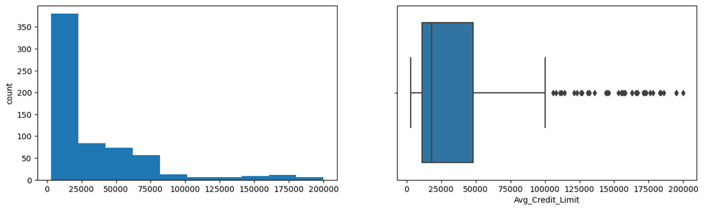

```
Total_Credit_Cards
Skew : 0.17
```

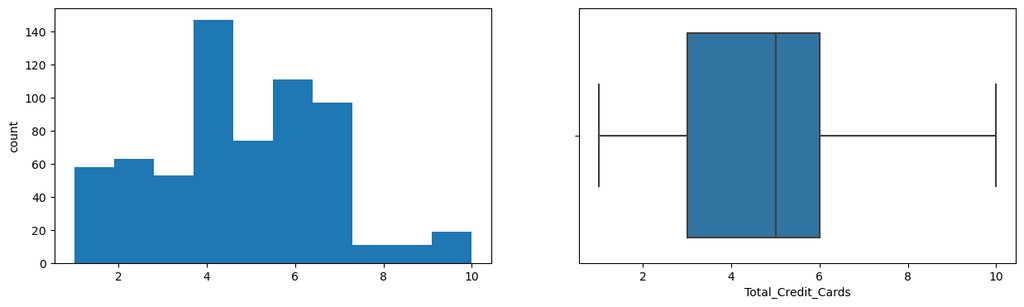

```
Total_visits_bank
Skew : 0.15
```

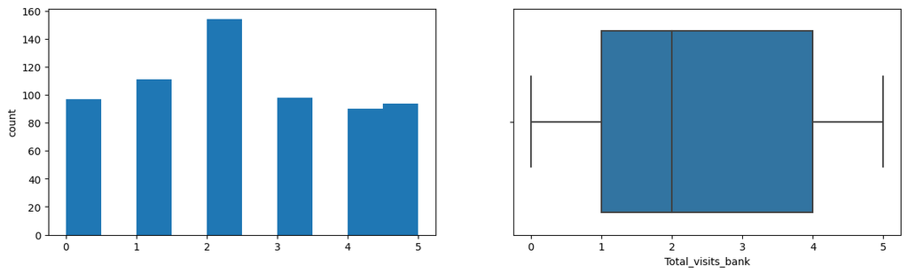

```
Total_visits_online
Skew : 2.21
```

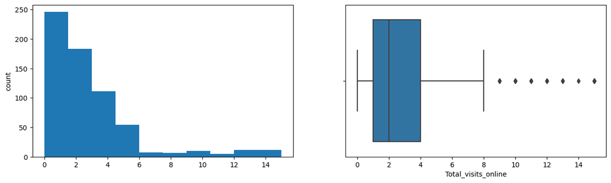

```
Total_calls_made
Skew : 0.65
```

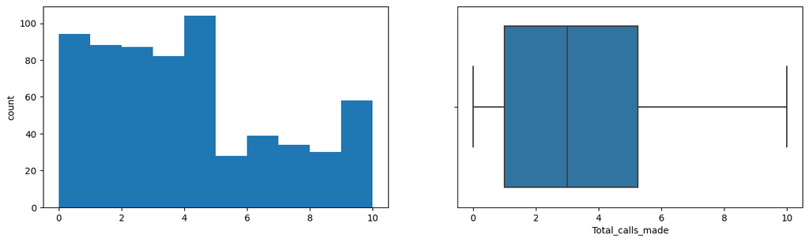

```python
for col in data.columns:
    print(col)
    print('Skew :', round(data[col].skew(), 2))
    plt.figure(figsize = (15, 4))
    plt.subplot(1, 2, 1)
    data[col].hist(bins = 10, grid = False)
    plt.ylabel('count')
    plt.subplot(1, 2, 2)
    sns.boxplot(x = data[col])
    plt.show()
```

**Observations:**

- Credit limit is highly skewed to the right with significant number of outliers.
- Number of credit cards, bank visits, calls made are slightly skewed to the right. No outliers.
- Online visit is highly skewd to the right with significant number of outliers.

### Bivariate Analysis

#### **Checking correlation**

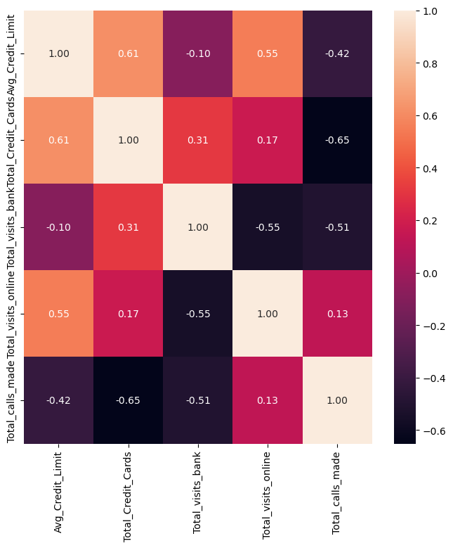

```python
plt.figure(figsize = (8, 8))
sns.heatmap(data.corr(), annot = True, fmt = '0.2f')
plt.show()
```

**Observations:**

### **Scaling the data**

Clustering algorithms are sensitive to the variances in the features (columns). Therefore its important the features have comparable scales

```python
scaler = StandardScaler()
#Standardizing each column of the data to have a mean of ~0 and a variance of 1
data_scaled = scaler.fit_transform(data)
```

### **Applying PCA on scaled data**

Principal component analysis helps project the data into a dimension (eigenvectors) that amplifiers or aid clustering

```python
#setting number of PCA components to number of feautures in the data:
n = data.shape[1]
# Creating a PCA object with n_componenents = n, and random_state = 1 for reproducibility:
pca = PCA(n_components=n, random_state = 1)
#fitting the scaled data into the PCA object created:
principal_components = pca.fit_transform(data_scaled)
# Save principal components (PCs) to a DataFrame
data_pca = pd.DataFrame(principal_components, columns = ['PC1', 'PC2', 'PC3', 'PC4', 'PC5'])
```

```python
data_pca.head()
```

|  | PC1 | PC2 | PC3 | PC4 | PC5 |
| --- | --- | --- | --- | --- | --- |
| 0 | 0.520075 | 0.513577 | 1.818726 | 1.227488 | -1.364728 |
| 1 | -1.420238 | 3.098904 | -0.881905 | 0.395162 | 0.366338 |
| 2 | 0.539699 | 0.815314 | 0.114006 | -1.030473 | -0.193124 |
| 3 | -0.352709 | 0.127433 | 0.568003 | -0.720864 | -0.330915 |
| 4 | 1.303723 | 3.640665 | -0.068361 | 0.513522 | 0.694618 |

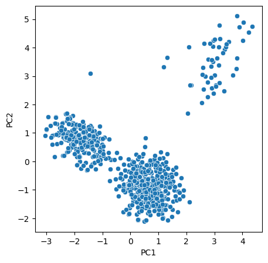

```python
#2D Visualization on PC-plane
plt.figure(figsize = (5,5))
sns.scatterplot(x = 'PC1', y = 'PC2', data = data_pca)
plt.show()
```

Observation:

- Its evident there are 3 clusters of customers. But I’ll use K-Means’ ELBOW method. to automatically detect the optimal number of clusters.

```python
# Creating copy of the pricipal components to store labels from each algorithm algorithm to be used
data_copy = data_pca.copy(deep = True)
```

## **K-Means** Clustering Algorithm

I will fit the K-means algorithm on our PCA components and find out the optimum number of clusters to us

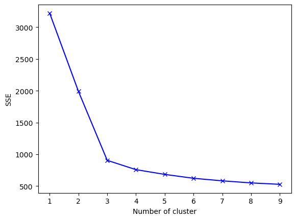

```python
# step 1 - Initialize a dictionary to store the Sum of Squared Error (SSE) for each K
sse = {}
# step 2 - iterate for a range of Ks and fit the pca components to the algorithm.
for k in range(1, 10):
    kmeans = KMeans(n_clusters = k, max_iter = 1000, random_state = 1).fit(data_pca)
    sse[k] = kmeans.inertia_ # Use inertia attribute from the clustering object and store the inertia value for that K
# step 3 - Plot the SSE vs K to visualize the elbow curve
plt.figure()
plt.plot(list(sse.keys()), list(sse.values()), 'bx-')
plt.xlabel("Number of cluster")
plt.ylabel("SSE")
plt.show()
```

**Observations:**

- Optimal number of clusters (3) is obtained at the elbow point of the SSE vs K curve. Consistent with visual observation from the principal component analysis earlier.

#### Now applying the K-Means clustering algorithm

```python
#creating a KMeans model with 3 clusters and random_state = 1 for reproducibilty
kmeans = KMeans(n_clusters = 3, random_state = 1)
# Fitting the created kmeans function on the pca components
kmeans.fit(data_pca)
# Adding predicted kmeans labels to the original dataset and the pca data
data_pca['Labels'] = kmeans.labels_
data['Labels'] = kmeans.labels_
```

I have now generated the labels with K-means. Now, I will look at the cluster profile with respect to various features

### **Creating cluster profiles using the below summary statistics and box plots for each label**

```python
# Number of observations in each cluster
data.Labels.value_counts()
```

```
1    374
0    221
2     49
Name: Labels, dtype: int64
```

```python
# Calculating summary statistics of the original data for each label
mean = data.groupby('Labels').mean()
median = data.groupby('Labels').median()

df_kmeans = pd.concat([mean, median], axis = 0)
df_kmeans.index = ['cluster_0 Mean', 'cluster_1 Mean', 'cluster_2 Mean', 'cluster_0 Median', 'cluster_1 Median', 'cluster_2 Median']

df_kmeans.T
```

|  | cluster_0 Mean | cluster_1 Mean | cluster_2 Mean | cluster_0 Median | cluster_1 Median | cluster_2 Median |
| --- | --- | --- | --- | --- | --- | --- |
| Avg_Credit_Limit | 12239.819005 | 33893.048128 | 140102.040816 | 12000.0 | 31500.0 | 145000.0 |
| Total_Credit_Cards | 2.411765 | 5.508021 | 8.775510 | 2.0 | 6.0 | 9.0 |
| Total_visits_bank | 0.945701 | 3.489305 | 0.591837 | 1.0 | 3.0 | 1.0 |
| Total_visits_online | 3.561086 | 0.975936 | 10.979592 | 4.0 | 1.0 | 11.0 |
| Total_calls_made | 6.891403 | 1.997326 | 1.102041 | 7.0 | 2.0 | 1.0 |

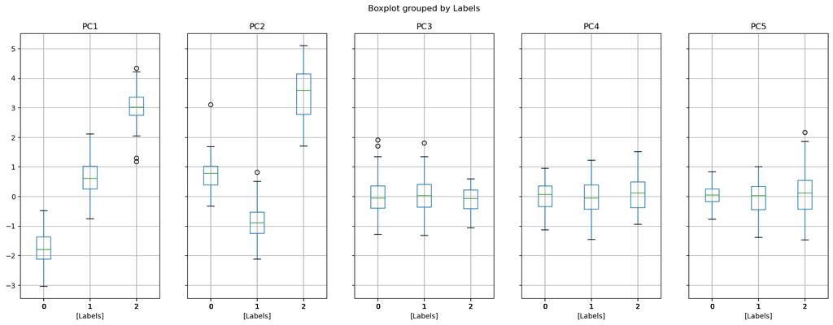

```python
# Visualizing different principal components w.r.t K-means labels
data_pca.boxplot(by = 'Labels', layout = (1, 5), figsize = (20, 7))
plt.show()
```

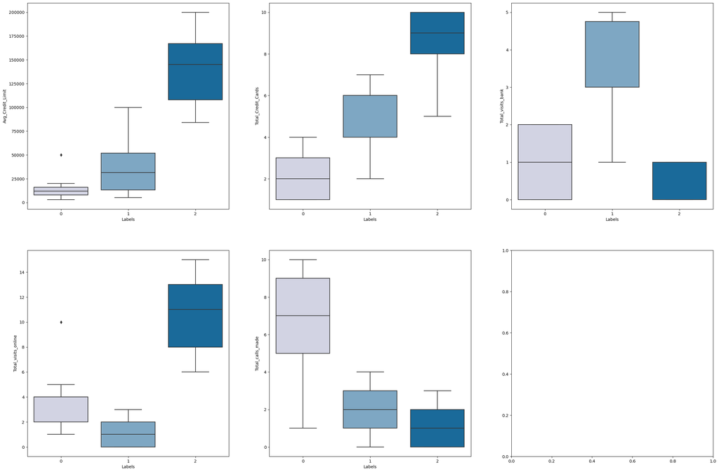

```python
# Visualizing different features of original data w.r.t K-means labels
fig, axes = plt.subplots(2, 3, figsize = (30, 20))
sns.boxplot(x = "Labels", y = "Avg_Credit_Limit", data = data, palette = 'PuBu',ax = axes[0,0])
sns.boxplot(x = "Labels", y = "Total_Credit_Cards", data = data, palette = 'PuBu',ax = axes[0,1])
sns.boxplot(x = "Labels", y = "Total_visits_bank", data = data, palette = 'PuBu',ax = axes[0,2])
sns.boxplot(x = "Labels", y = "Total_visits_online", data = data, palette = 'PuBu',ax = axes[1,0])
sns.boxplot(x = "Labels", y = "Total_calls_made", data = data, palette = 'PuBu',ax = axes[1,1])
```

### **KMean Cluster Profile:**

- **Cluster 0**: customers with low credit limit and few credit cards who tend to make a lot of calls and sometimes visit the bank or bank online. This appears to be RECENT personal bankers not so familiar with the bank's tech and are having a lot of issues with there the accounts.
- **Cluster 1**: customers with moderate credit limit and more credit cards who tend to visit the bank a lot more, rarely use online banking and sometimes call the bank. This appears to be SEASONED customers not so tech savvy or enjoy OLD-FASHION banking experience
- **Cluster 2**: customers with high credit limit and lots of credit cards who mostly bank online, rarely visit the bank or call in. This apears to be a group of BUSINESS owners and who prefer ONLINE banking for ease.

```python
#dropping KMeans label from original data and the pca data since i have no use for them anymore
data.drop(columns = 'Labels', inplace = True)
data_pca.drop(columns = 'Labels', inplace = True)
```

```python
data.shape,data_pca.shape
```

```
((644, 5), (644, 5))
```

## **Gaussian Mixture Model**

I will now apply the Gaussian Mixture algorithm on the PCA components to create clusters

```python
#creating a Gaussian Mixture model with n_components = 3 and random_state = 1 for reproducibilty
gmm = GaussianMixture(n_components = 3, random_state = 1)
#fitting the GMModel on the pca components
gmm.fit(data_pca)
#Adding predicted GMM labels to the original dataset and the pca data
X =  gmm.predict(data_pca)
data_pca['GmmLabels'] = X
data['GmmLabels'] = X
```

```python
# Number of observations in each cluster
data.GmmLabels.value_counts()
```

```
1    374
0    221
2     49
Name: GmmLabels, dtype: int64
```

```python
# Calculating the summary statistics of the original data for each label
original_features = ["Avg_Credit_Limit", "Total_Credit_Cards", "Total_visits_bank", "Total_visits_online", "Total_calls_made"]

mean = data.groupby('GmmLabels').mean()
median = data.groupby('GmmLabels').median()

df_gmm = pd.concat([mean, median], axis = 0)
df_gmm.index = ['cluster_0 Mean', 'cluster_1 Mean', 'cluster_2 Mean', 'cluster_0 Median', 'cluster_1 Median', 'cluster_2 Median']
#df_gmm.column = ["Avg_Credit_Limit(GMM)", "Total_Credit_Cards(GMM)", "Total_visits_bank(GMM)", "Total_visits_online(GMM)", "Total_calls_made(GMM)"]

df_gmm[original_features].T  #df_gmm.T does the same
```

|  | cluster_0 Mean | cluster_1 Mean | cluster_2 Mean | cluster_0 Median | cluster_1 Median | cluster_2 Median |
| --- | --- | --- | --- | --- | --- | --- |
| Avg_Credit_Limit | 12239.819005 | 33893.048128 | 140102.040816 | 12000.0 | 31500.0 | 145000.0 |
| Total_Credit_Cards | 2.411765 | 5.508021 | 8.775510 | 2.0 | 6.0 | 9.0 |
| Total_visits_bank | 0.945701 | 3.489305 | 0.591837 | 1.0 | 3.0 | 1.0 |
| Total_visits_online | 3.561086 | 0.975936 | 10.979592 | 4.0 | 1.0 | 11.0 |
| Total_calls_made | 6.891403 | 1.997326 | 1.102041 | 7.0 | 2.0 | 1.0 |

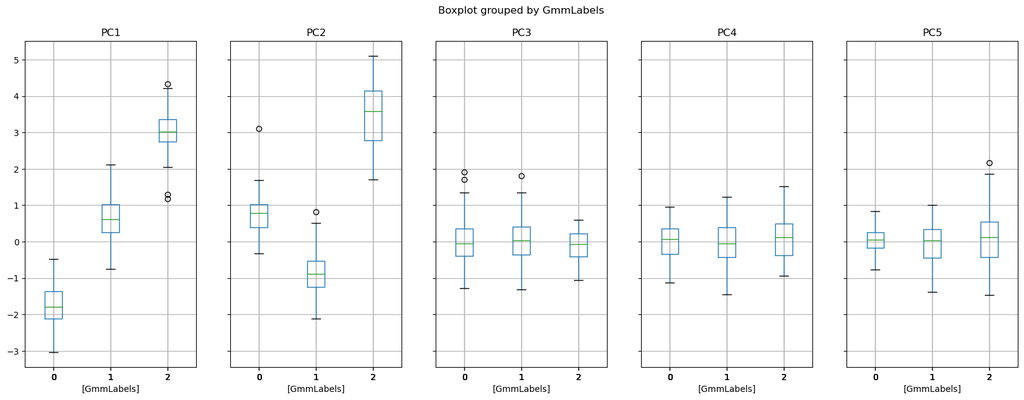

```python
# Visualizing different principal components w.r.t GMM labels
data_pca.boxplot(by = 'GmmLabels', layout = (1, 5),figsize = (20, 7))
plt.show()
```

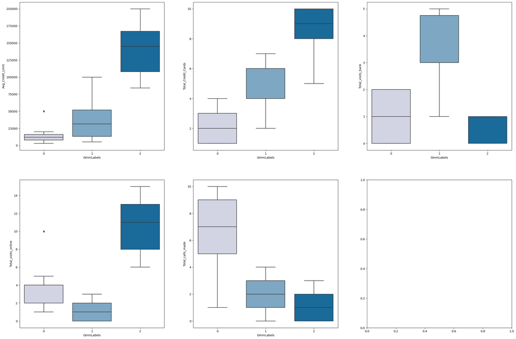

```python
# Visualizing different features of original data w.r.t GMM labels
fig, axes = plt.subplots(2, 3, figsize = (30, 20))
sns.boxplot(x = "GmmLabels", y = "Avg_Credit_Limit", data = data, palette = 'PuBu',ax = axes[0,0])
sns.boxplot(x = "GmmLabels", y = "Total_Credit_Cards", data = data, palette = 'PuBu',ax = axes[0,1])
sns.boxplot(x = "GmmLabels", y = "Total_visits_bank", data = data, palette = 'PuBu',ax = axes[0,2])
sns.boxplot(x = "GmmLabels", y = "Total_visits_online", data = data, palette = 'PuBu',ax = axes[1,0])
sns.boxplot(x = "GmmLabels", y = "Total_calls_made", data = data, palette = 'PuBu',ax = axes[1,1])
```

### **GMM Cluster Profile:**

- **Cluster 0**: customers with low credit limit and few credit cards who tend to make a lot of calls and sometimes visit the bank or bank online. This appears to be RECENT personal bankers not so familiar with the bank's tech and are having a lot of issues with there the accounts.
- **Cluster 1**: customers with moderate credit limit and more credit cards who tend to visit the bank a lot more, rarely use online banking and sometimes call the bank. This appears to be SEASONED customers not so tech savvy or enjoy OLD-FASHION banking experience
- **Cluster 2**: customers with high credit limit and lots of credit cards who mostly bank online, rarely visit the bank or call in. This apears to be a group of BUSINESS owners and who prefer ONLINE banking for ease.

**GMM Cluster Profile very similar to KMean cluster profile discussed earlier**

```python
#dropping GMM label from original data and the pca data since i have no use for them anymore
data.drop(columns = 'GmmLabels', inplace = True)
data_pca.drop(columns = 'GmmLabels', inplace = True)
```

```python
data.shape,data_pca.shape
```

```
((644, 5), (644, 5))
```

## **K-Medoids** Clustering Algorithm

```python
#creating kmedoids model with n_components=3 and random_state=1 for reproducibility
kmedo = KMedoids(n_clusters=3, random_state = 1)
# Fit the model on the pca components
kmedo.fit(data_pca)
#Adding predicted KMedoid labels to the original dataset and the pca data
data_pca['kmedoLabels'] = kmedo.labels_
data['kmedoLabels'] = kmedo.labels_
```

```python
# Number of observations in each cluster
data.kmedoLabels.value_counts()
```

```
2    289
0    222
1    133
Name: kmedoLabels, dtype: int64
```

```python
# Calculating summary statistics of the original data for each label
mean = data.groupby('kmedoLabels').mean()
median = data.groupby('kmedoLabels').median()

df_kmedoids = pd.concat([mean, median], axis = 0)
df_kmedoids.index = ['cluster_0 Mean', 'cluster_1 Mean', 'cluster_2 Mean', 'cluster_0 Median', 'cluster_1 Median', 'cluster_2 Median']

df_kmedoids[original_features].T  #no need for [original_features] since labels from previous algorithm has been removed from data and data_pca
```

|  | cluster_0 Mean | cluster_1 Mean | cluster_2 Mean | cluster_0 Median | cluster_1 Median | cluster_2 Median |
| --- | --- | --- | --- | --- | --- | --- |
| Avg_Credit_Limit | 12216.216216 | 85052.631579 | 28449.826990 | 12000.0 | 68000.0 | 20000.0 |
| Total_Credit_Cards | 2.423423 | 7.030075 | 5.363322 | 2.0 | 7.0 | 5.0 |
| Total_visits_bank | 0.950450 | 1.691729 | 3.830450 | 1.0 | 2.0 | 4.0 |
| Total_visits_online | 3.554054 | 4.639098 | 0.982699 | 4.0 | 2.0 | 1.0 |
| Total_calls_made | 6.878378 | 1.969925 | 1.851211 | 7.0 | 2.0 | 2.0 |

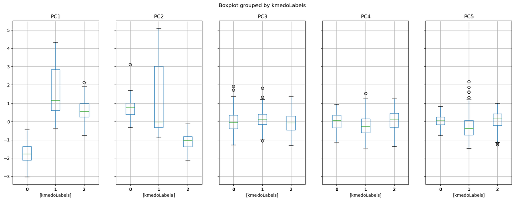

```python
#Visualizing different principal components w.r.t new K-Medoids labels
data_pca.boxplot(by = 'kmedoLabels', layout = (1, 5), figsize = (20, 7))
plt.show()
```

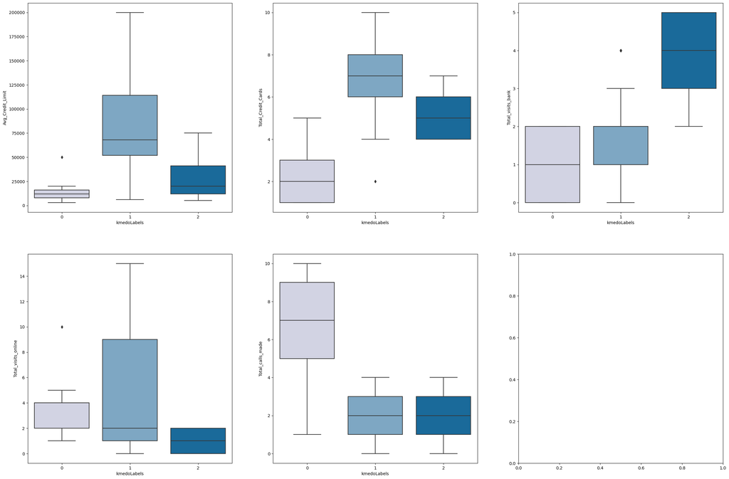

```python
# Visualizing different features of original data w.r.t KMedoids labels
fig, axes = plt.subplots(2, 3, figsize = (30, 20))
sns.boxplot(x = "kmedoLabels", y = "Avg_Credit_Limit", data = data, palette = 'PuBu',ax = axes[0,0])
sns.boxplot(x = "kmedoLabels", y = "Total_Credit_Cards", data = data, palette = 'PuBu',ax = axes[0,1])
sns.boxplot(x = "kmedoLabels", y = "Total_visits_bank", data = data, palette = 'PuBu',ax = axes[0,2])
sns.boxplot(x = "kmedoLabels", y = "Total_visits_online", data = data, palette = 'PuBu',ax = axes[1,0])
sns.boxplot(x = "kmedoLabels", y = "Total_calls_made", data = data, palette = 'PuBu',ax = axes[1,1])
```

```python
#dropping KMedoid label from original data and the pca data since i have no use for them anymore
data.drop(columns = 'kmedoLabels', inplace = True)
data_pca.drop(columns = 'kmedoLabels', inplace = True)
```

### **KMedoids Cluster Profile:**

- **Cluster 0**: customers with very low credit limit and few credit cards who tend to make a lot of calls and sometimes visit the bank or bank online. This appears to be RECENT personal bankers not so familiar with the bank's tech and are having a lot of issues with there the accounts.
- **Cluster 1**: customers with high credit limit and lots of credit cards who tend to visit the bank, use online banking and sometimes call the bank. This appears to be BUSINESS customers who are comfortable with using all channels of reaching the bank.
- **Cluster 2**: customers with low credit limit and a few more credit cards who mostly visit the bank, rarely use online bank and sometimes call in. This apears to be a group of financially CHALLENGED customers who mostly walk in to resolve issues.

I'll compare the clusters from K-Means and K-Medoids

```python
comparison = pd.concat([df_kmedoids, df_kmeans], axis = 1)[original_features]
round(comparison,2)
```

|  | Avg_Credit_Limit | Avg_Credit_Limit | Total_Credit_Cards | Total_Credit_Cards | Total_visits_bank | Total_visits_bank | Total_visits_online | Total_visits_online | Total_calls_made | Total_calls_made |
| --- | --- | --- | --- | --- | --- | --- | --- | --- | --- | --- |
| cluster_0 Mean | 12216.22 | 12239.82 | 2.42 | 2.41 | 0.95 | 0.95 | 3.55 | 3.56 | 6.88 | 6.89 |
| cluster_1 Mean | 85052.63 | 33893.05 | 7.03 | 5.51 | 1.69 | 3.49 | 4.64 | 0.98 | 1.97 | 2.00 |
| cluster_2 Mean | 28449.83 | 140102.04 | 5.36 | 8.78 | 3.83 | 0.59 | 0.98 | 10.98 | 1.85 | 1.10 |
| cluster_0 Median | 12000.00 | 12000.00 | 2.00 | 2.00 | 1.00 | 1.00 | 4.00 | 4.00 | 7.00 | 7.00 |
| cluster_1 Median | 68000.00 | 31500.00 | 7.00 | 6.00 | 2.00 | 3.00 | 2.00 | 1.00 | 2.00 | 2.00 |
| cluster_2 Median | 20000.00 | 145000.00 | 5.00 | 9.00 | 4.00 | 1.00 | 1.00 | 11.00 | 2.00 | 1.00 |

## Hierarchical Clustering

```python
# Clustering with 3 clusters
hierarchical = AgglomerativeClustering(n_clusters = 3, affinity = 'euclidean', linkage = 'complete')
hierarchical.fit(data_pca)
data_pca['HCLabels'] = hierarchical.labels_
data['HCLabels'] = hierarchical.labels_
```

```python
data.HCLabels.value_counts()
```

```
0    376
2    219
1     49
Name: HCLabels, dtype: int64
```

```python
# Calculating summary statistics of the original data for each label
mean = data.groupby('HCLabels').mean()
median = data.groupby('HCLabels').median()

df_HC = pd.concat([mean, median], axis = 0)
df_HC.index = ['cluster_0 Mean', 'cluster_1 Mean', 'cluster_2 Mean', 'cluster_0 Median', 'cluster_1 Median', 'cluster_2 Median']

df_HC.T
```

|  | cluster_0 Mean | cluster_1 Mean | cluster_2 Mean | cluster_0 Median | cluster_1 Median | cluster_2 Median |
| --- | --- | --- | --- | --- | --- | --- |
| Avg_Credit_Limit | 33704.787234 | 140102.040816 | 12365.296804 | 31000.0 | 145000.0 | 12000.0 |
| Total_Credit_Cards | 5.489362 | 8.775510 | 2.415525 | 6.0 | 9.0 | 2.0 |
| Total_visits_bank | 3.473404 | 0.591837 | 0.949772 | 3.0 | 1.0 | 1.0 |
| Total_visits_online | 0.981383 | 10.979592 | 3.575342 | 1.0 | 11.0 | 4.0 |
| Total_calls_made | 1.994681 | 1.102041 | 6.940639 | 2.0 | 1.0 | 7.0 |

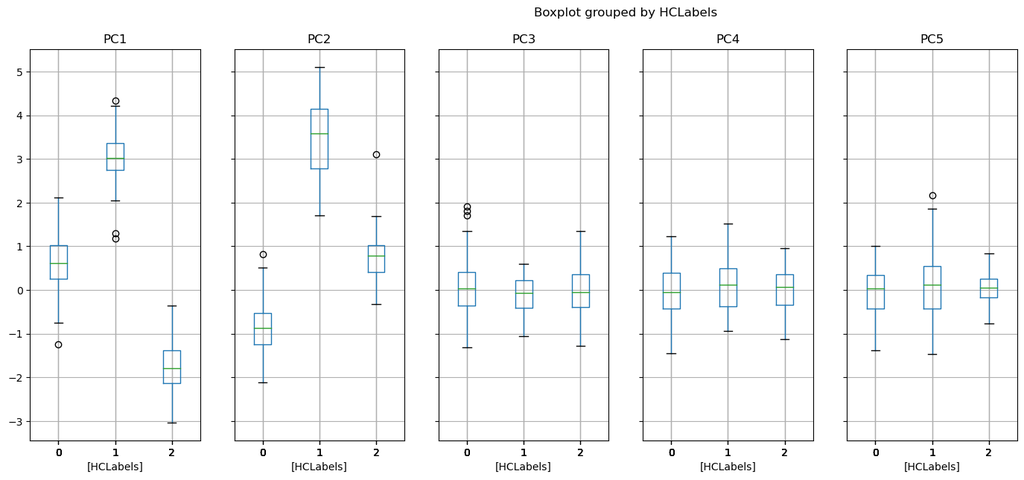

```python
#Visualizing different principal components w.r.t new HC labels
data_pca.boxplot(by = 'HCLabels', layout = (1, 6), figsize = (20, 7))
plt.show()
```

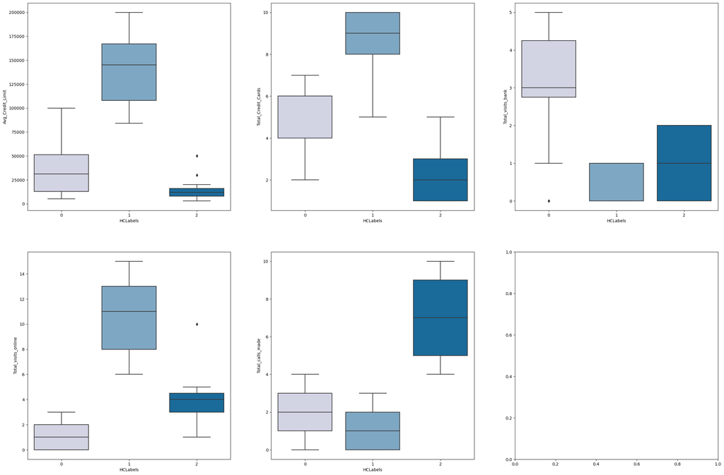

```python
# Visualizing different features of original data w.r.t HC labels
fig, axes = plt.subplots(2, 3, figsize = (30, 20))
sns.boxplot(x = "HCLabels", y = "Avg_Credit_Limit", data = data, palette = 'PuBu',ax = axes[0,0])
sns.boxplot(x = "HCLabels", y = "Total_Credit_Cards", data = data, palette = 'PuBu',ax = axes[0,1])
sns.boxplot(x = "HCLabels", y = "Total_visits_bank", data = data, palette = 'PuBu',ax = axes[0,2])
sns.boxplot(x = "HCLabels", y = "Total_visits_online", data = data, palette = 'PuBu',ax = axes[1,0])
sns.boxplot(x = "HCLabels", y = "Total_calls_made", data = data, palette = 'PuBu',ax = axes[1,1])
```

## **Business Insights and Recommendations**

- There are essentially 3 groups of customers in the data. These groups are different in there spending pattern and preferred way of reaching the bank
- There appears to be a group of RECENT customers with low credit limit and fewer cards who appear to be having difficulty using or not inclined to use the online banking. An awareness campaign to show the ease and benefit of online banking is needed. This will help reduce traffic experienced at the call centre.
- A second cluster is a group of SEASONED customers who seem to enjoy the OLD-FASHION banking experience of walking in. The positive experience they have while visiting the bank needs to be sustained. A special campaign to brand online banking could be targeted towards these customers that prefer to walk into the banking hall.
- BUSINESS customers appear to favour online banking experience. This needs to be sustained.